# Self-reported expressibility predicts communicative success: Open dataset, validation, and simulation

# 7 Hypothesis 3: Guessability vs. experiment part

*Guessability is higher when there is feedback between a producer and a guesser (i.e., in the second half of the experiment, where the guesser knows if they answered correctly, and the producer knows what the guesser answered).*

## 7.1 Guess binary

Preregistered model: `guessability_match ~ experiment_part + (1 | dyad/participant) + (1 | concept), family = bernoulli(link = 'logit')`

```r
mdl_H3_binary <- readRDS(paste0(models, "mdl_H3_binary.rds"))
```

Calculate R².

```
##     Estimate   Est.Error      Q2.5    Q97.5
## R2 0.2151312 0.006364767 0.2024922 0.227499
```

R^2 is 0.2151312 suggesting that 21.5131241% of the variance in the outcome variable are explained by the model.

**Diagnostic plots**:

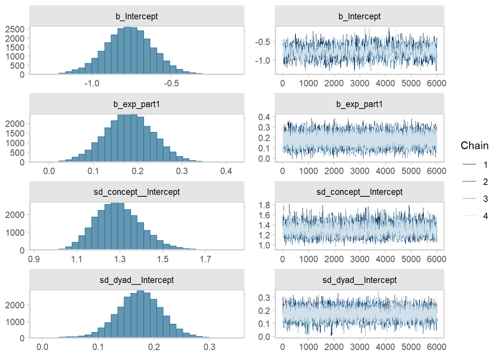

```r
plot(mdl_H3_binary)
```

**Convergence**: All convergence diagnostics are excellent (Rhat = 1.00).

```r
summary(mdl_H3_binary)
```

```
##  Family: bernoulli
##   Links: mu = logit
## Formula: guess_binary ~ exp_part + (1 | dyad) + (1 | concept)
##    Data: df (Number of observations: 8989)
##   Draws: 4 chains, each with iter = 10000; warmup = 4000; thin = 1;
##          total post-warmup draws = 24000
##
## Multilevel Hyperparameters:
## ~concept (Number of levels: 84)
##               Estimate Est.Error l-95% CI u-95% CI Rhat Bulk_ESS Tail_ESS
## sd(Intercept)     1.29      0.11     1.10     1.53 1.00     4085     8423
##
## ~dyad (Number of levels: 71)
##               Estimate Est.Error l-95% CI u-95% CI Rhat Bulk_ESS Tail_ESS
## sd(Intercept)     0.17      0.04     0.09     0.25 1.00     7959     7101
##
## Regression Coefficients:
##           Estimate Est.Error l-95% CI u-95% CI Rhat Bulk_ESS Tail_ESS
## Intercept    -0.77      0.15    -1.07    -0.48 1.00     1630     2982
## exp_part1     0.18      0.06     0.07     0.29 1.00    47311    17441
##
## Draws were sampled using sampling(NUTS). For each parameter, Bulk_ESS
## and Tail_ESS are effective sample size measures, and Rhat is the potential
## scale reduction factor on split chains (at convergence, Rhat = 1).
```

```
## No divergences to plot.
```

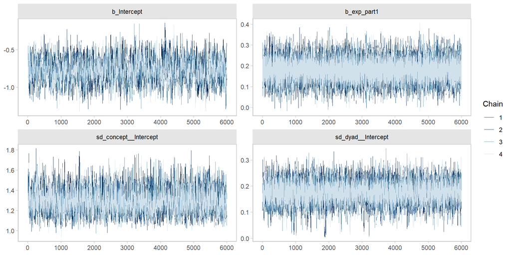

**Figure 52.** Trace of the fitting process. Figure generated using [`R`](https://www.r-project.org/) version 4.4.1 (2024-06-14 ucrt)

```r
mcmc_plot(mdl_H3_binary, type="trace");
```

**Posterior predictive checks**: Looking good.

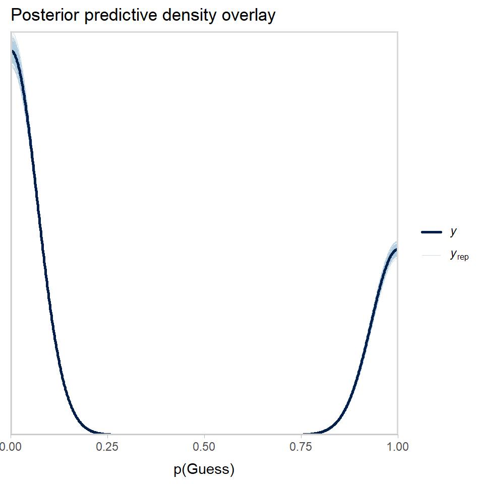

**Figure 53.** Posterior predictive density overlay for n=500 draws. Figure generated using [`R`](https://www.r-project.org/) version 4.4.1 (2024-06-14 ucrt)

```r
pp_check(mdl_H3_binary, ndraws=500) + xlab('p(Guess)') + ggtitle('Posterior predictive density overlay');
```

```
## Using all posterior draws for ppc type 'stat' by default.
## Using all posterior draws for ppc type 'stat' by default.
## Using all posterior draws for ppc type 'stat' by default.
```

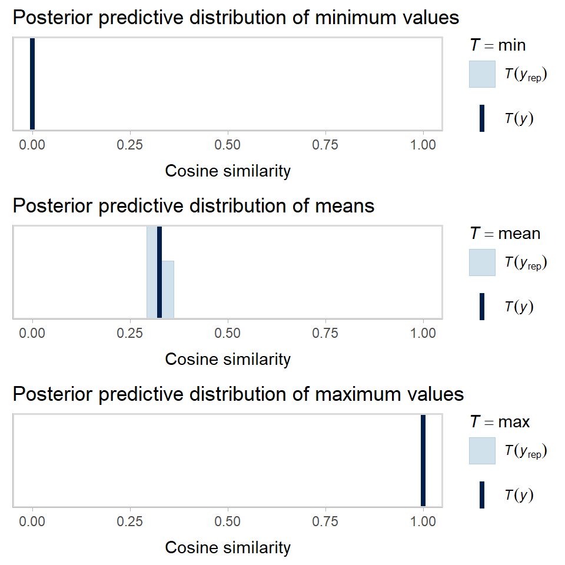

**Figure 54.** Posterior predictive distribution. Figure generated using [`R`](https://www.r-project.org/) version 4.4.1 (2024-06-14 ucrt)

```r
grid.arrange(pp_check(mdl_H3_binary, type='stat', sta ='min') + xlab('Cosine similarity') + ggtitle('Posterior predictive distribution of minimum values') + xlim(0,1),
             pp_check(mdl_H3_binary, type='stat', stat='mean') + xlab('Cosine similarity') + ggtitle('Posterior predictive distribution of means') + xlim(0,1),
             pp_check(mdl_H3_binary, type='stat', stat='max') + xlab('Cosine similarity') + ggtitle('Posterior predictive distribution of maximum values') + xlim(0,1),
             ncol=1);
```

**Fixed effects**:

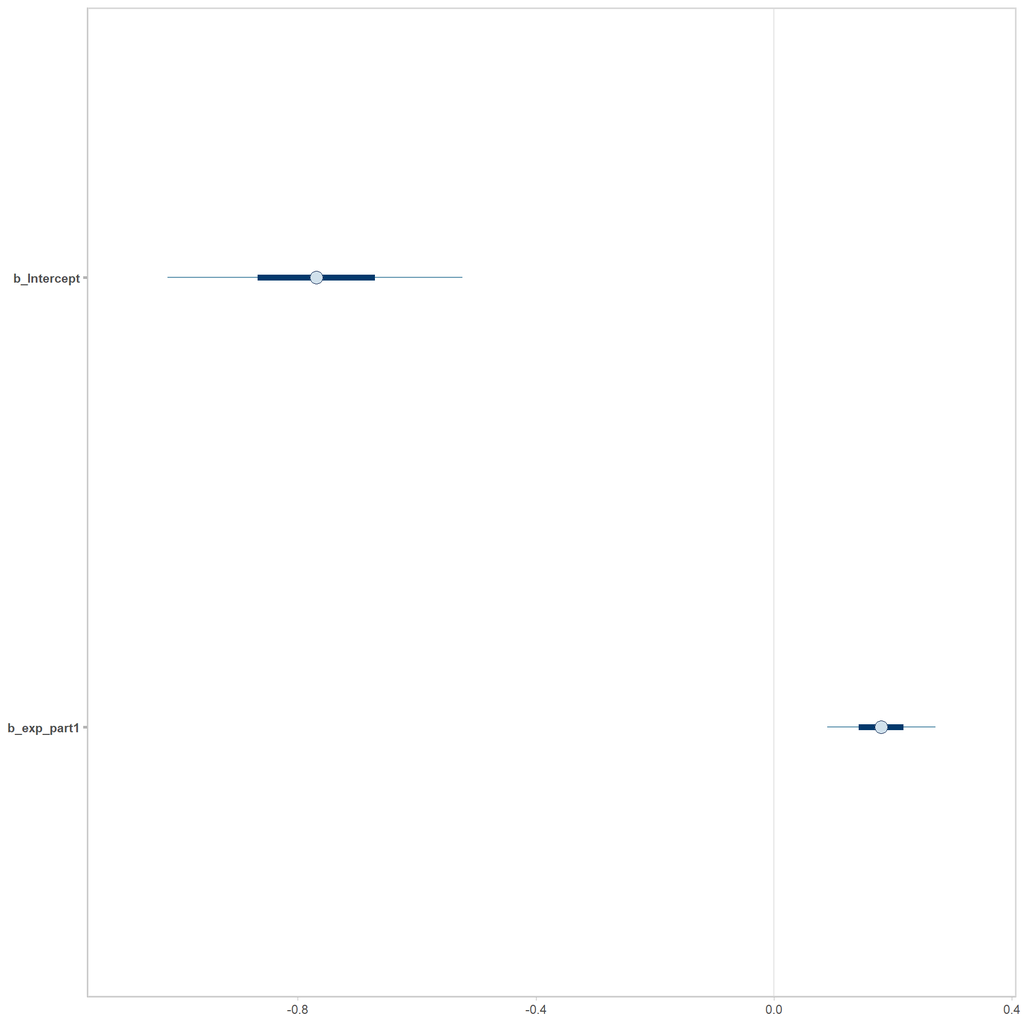

**Figure 55.** Fixed effects’ posterior distributions. Figure generated using [`R`](https://www.r-project.org/) version 4.4.1 (2024-06-14 ucrt)

```r
mcmc_plot(mdl_H3_binary, variable = c("b_Intercept", "b_exp_part1"));
```

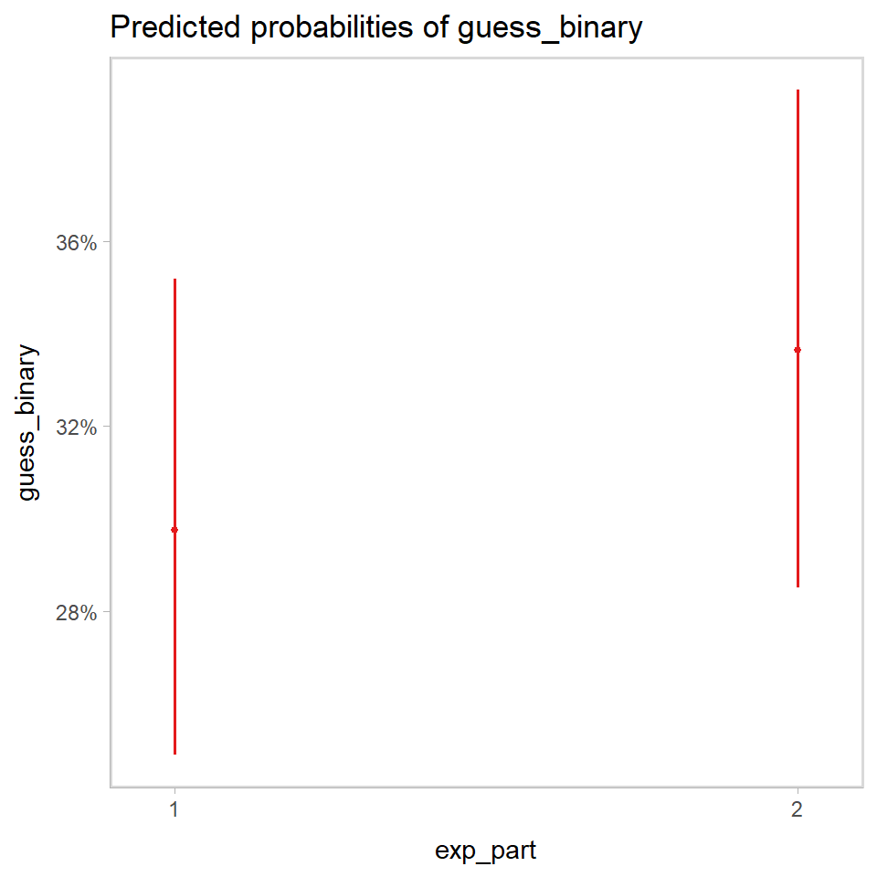

**Figure 56.** Fixed effects. Figure generated using [`R`](https://www.r-project.org/) version 4.4.1 (2024-06-14 ucrt)

```r
plot_model(mdl_H3_binary, type="emm", terms=c("exp_part"));
```